# Stent treatment simulation

### Case Study: Using stents to prevent strokes

Stents are devices put inside blood vessels that assist in patient recovery after cardiac events, and they have been shown to reduce the risk of an additional heart attack or death.

Many doctors have hoped that there would be similar benefits for patients at risk of stroke.

Research Question: Does the use of stents reduce the risk of stroke?

#### Recall our data set

```
##            outcome
## group       no event stroke
##   control        199     28
##   treatment      179     45
```

- 451 total patients, 224 of them in treatment group
- 73 total patients had stroke event in the one year time period
- 45 patients in treatment group had a stroke event

Suppose that in this group of 451 patients, 73 would have had a stroke event during the year *regardless* of which group they were in.

**Key Question**: In this case, how likely is it to get 45 (or more) stroke events in the treatment group?

#### Create a deck of cards reflecting these results

We can attack the key question via simulation!

First, create a *deck* of 451 cards so that 73 of them have ‘s’ printed on them (for stroke event), the rest have ‘n’.

```r
deck <- rep(c("n","s"),times=c(378,73))
table(deck)
```

```
## deck
##   n   s
## 378  73
```

#### Simulate

We shuffle the deck, randomly deal 224 cards into Treatment group, and see how many ‘s’ cards we get.

```r
sim1 <- sample(deck)[1:224]
table(sim1)
```

```
## sim1
##   n   s
## 181  43
```

#### Simulate again

```r
sim2 <- sample(deck)[1:224]
table(sim2)
```

```
## sim2
##   n   s
## 189  35
```

#### Simulate a third time

```r
sim3 <- sample(deck)[1:224]
table(sim3)
```

```
## sim3
##   n   s
## 178  46
```

We should expect to get different ‘s’ counts from different samples.

In our three simulations we saw these results: 43, 35, 46

What range of results should we expect if we continued this game? And how likely is it to get 45 or more on any given trial?

If we simulatw a *bunch* of times, we can address these types of questions.

#### Simulate many, many times at once

```r
trials=5000
  results<-c()
  for(x in 1:trials)
    {results<-c(results,table(sample(deck)[1:224])['s'])}
```

Running this simulation 5000 times, we asked R to record the results in the vector `results`. With the code below, we can find how often the treatment group had at least 45 stroke events in these in these 5000 trials.

```r
sum(results>=45)
```

```
## [1] 96
```

The proportion of the trials with at least 45 stroke events:

```r
sum(results>=45)/trials
```

```
## [1] 0.0192
```

In other words, such an extreme number of stroke events would occured in about 1.9% of these trials.

#### Plotting the distribution for these trials

We can also plot a histogram of our simulation results to get a sense of how many ’s’ cards are likely to turn up in any given trial.

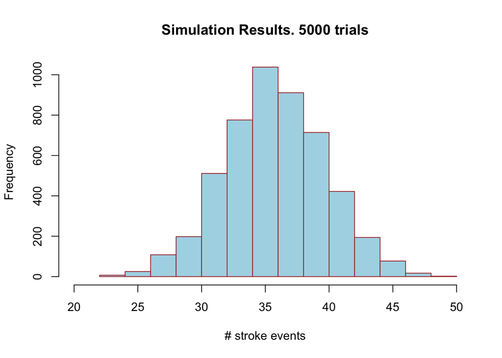

#### Conclusion

- If we assume the treatments have no effect on the 451 patients in this group, and that 73 of these patients would have had a stroke event in the first year, regardless of treatment, then it is *very unlikely* that among 224 randomly chosen patients from the group, 45 or more of them would have a stroke event.
- In fact, our simulation of 5000 trials suggests that such an extreme result happens about 1.9% of the time.
- The researchers originally asked whether the use of stents *reduced* the rate of strokes, and the data clearly do not support this claim. In fact, after running this simulation, I am led to consider that the treatment actually makes a stroke more likely, because in the experiment 45 of the patients in the treatment group actually did suffer a stroke event in the first year, something that would happen very rarely if the stent made no difference.